# Laporan Publikasi Bersama Mahasiswa S2 Statistika Terapan dan Dosen

[figure not shown]

Lembar Pengesahan

Laporan ini disusun sebagai ringkasan resmi hasil pemetaan publikasi bersama mahasiswa S2 Statistika Terapan dan dosen, dengan fokus hanya pada data yang telah terverifikasi.

Data bersihVerified only

Jatinangor, 9 Agustus 2026

Ketua Program Studi S2 Statistika Terapan

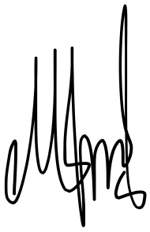

**Dr. I Gede Nyoman Mindra Jaya, S.Si., M.Si.**

Kata Pengantar

Laporan ini menyajikan hasil pemetaan publikasi bersama mahasiswa S2 Statistika Terapan dan dosen FMIPA Universitas Padjadjaran berdasarkan dataset yang telah dibersihkan. Seluruh elemen laporan ini telah direvisi agar lebih rapi, bersih, dan hanya menampilkan data terverifikasi. Dengan demikian, grafik, tabel, dan interpretasi yang tersaji dapat digunakan sebagai bahan dokumentasi akademik, evaluasi internal, maupun pendukung pelaporan institusi.

Perbaikan utama pada versi ini meliputi penggunaan cover resmi, penguatan tampilan visual, penggantian grafik menjadi lebih profesional dan berwarna, serta penghapusan seluruh bagian yang menampilkan status belum terverifikasi. Diharapkan laporan ini memberikan gambaran yang lebih akurat mengenai capaian kolaborasi publikasi, kualitas indeksasi, dan arah pengembangan budaya riset di lingkungan program studi.

Ringkasan Eksekutif

Dashboard singkat ini hanya menggunakan **data terverifikasi**.

64

Publikasi Terverifikasi

62/118

Mahasiswa Tercover

25

Jurnal Internasional

25

Publikasi Q1–Q4

Catatan: tidak ada data belum terverifikasi yang ditampilkan pada versi HTML ini.

Analisis Mendalam

1. Dataset akhir hanya memuat **64 publikasi terverifikasi**. Seluruh analisis pada laporan ini dibangun dari publikasi yang sudah tervalidasi memuat setidaknya satu nama mahasiswa dan satu nama dosen dari daftar acuan.
2. Dari sisi cakupan kolaborasi, terdapat **62 mahasiswa** yang sudah muncul pada publikasi terverifikasi, atau sekitar **52.5%** dari total daftar 118 mahasiswa.
3. Internasionalisasi publikasi terlihat kuat, dengan **25 jurnal internasional** atau sekitar **39.1%** dari seluruh publikasi terverifikasi.
4. Kualitas indeks juga menunjukkan sinyal positif: terdapat **25 publikasi** yang telah memiliki identifikasi quartile Scopus, terdiri atas **11 Q1**, **1 Q2**, **11 Q3**, dan **2 Q4**. Ini berarti sekitar **48.0%** dari publikasi berquartile berada pada kelas atas (Q1–Q2).
5. Pada publikasi nasional, terdapat **24 publikasi** dengan peringkat SINTA yang berhasil diidentifikasi. Sebaran terbesar berada pada SINTA 2–3, menandakan kombinasi yang sehat antara target kualitas dan produktivitas terapan.
6. Dari sisi jejaring akademik, terbentuk **132 pasangan unik mahasiswa–dosen**, yang menunjukkan struktur kolaborasi yang cukup kaya dan tidak hanya bergantung pada satu atau dua penulis inti saja.

Visualisasi Data Terverifikasi

#### Tren publikasi per tahun

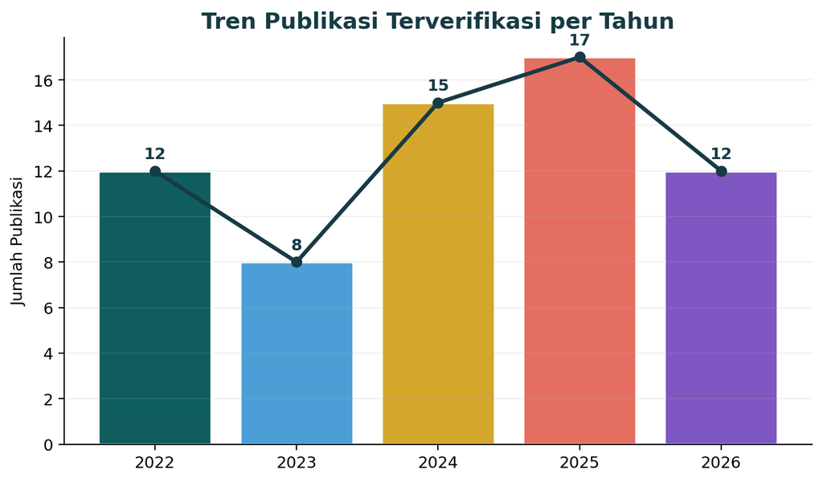

#### Komposisi jenis publikasi

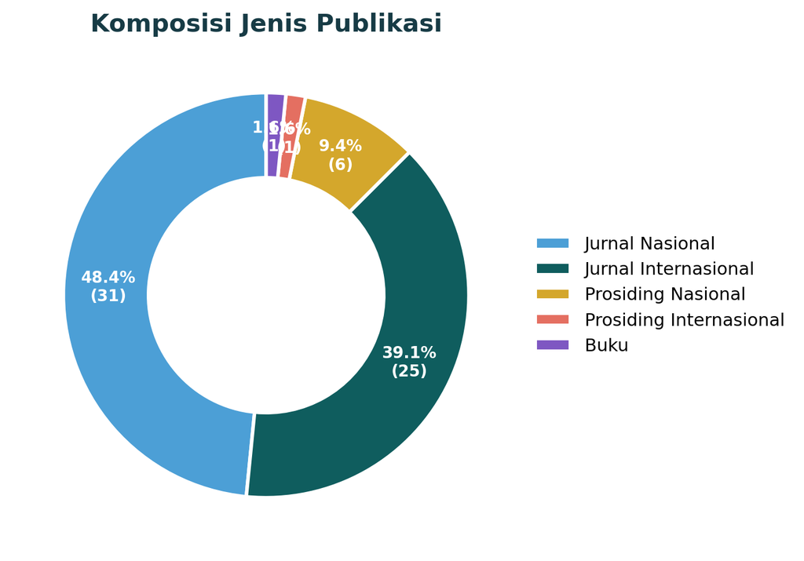

#### Distribusi quartile Scopus

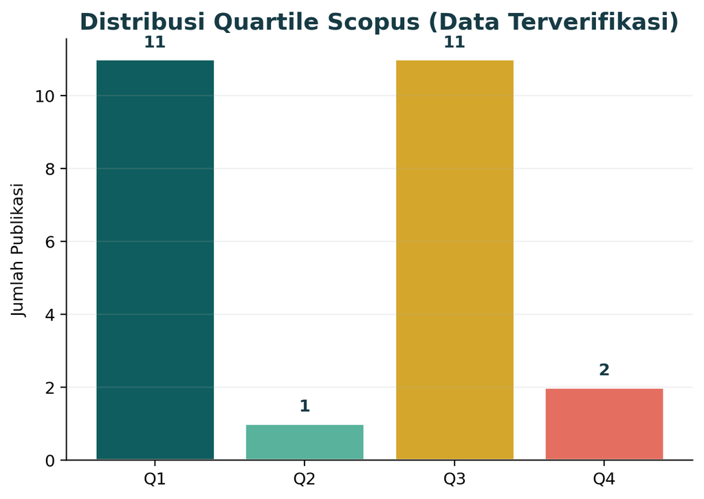

#### Distribusi peringkat SINTA

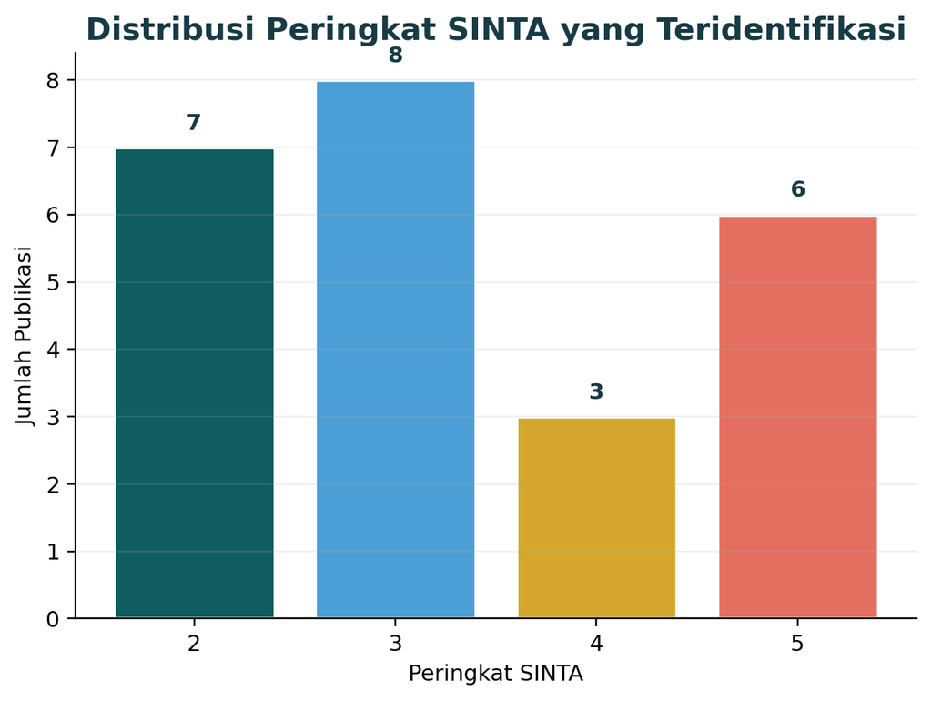

#### Kontribusi dosen

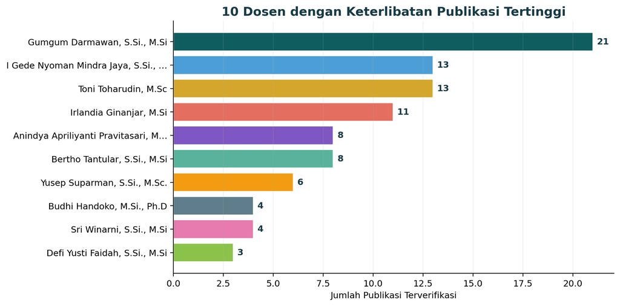

#### Tema metodologis dominan

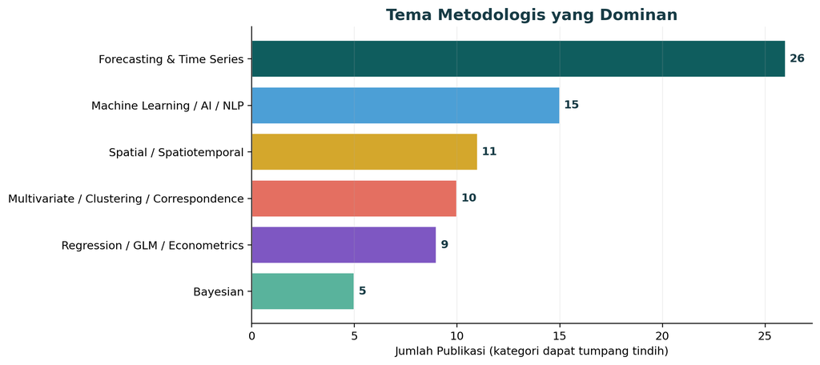

Metodologi Penyaringan Data

- Publikasi dimasukkan hanya jika statusnya terverifikasi dan memuat minimal satu nama mahasiswa serta satu nama dosen dari daftar acuan.
- Semua elemen non-verifikasi telah dikeluarkan dari tampilan HTML dan DOCX agar laporan tetap bersih dan fokus.
- Analisis, grafik, dan tabel pada laporan ini tidak menampilkan data yang tidak terverifikasi.
- Nilai SINTA dan quartile Scopus ditampilkan hanya bila berhasil diidentifikasi dari sumber yang relevan; selain itu diberi tanda “–”.

Lampiran — Publikasi Terverifikasi

Menampilkan **64** publikasi yang sudah lolos verifikasi.

| No. | Nama Dosen | Nama Mahasiswa | Judul Penelitian | Tahun | Jenis | SINTA | Scopus | Jurnal / Prosiding / Penerbit | DOI | Tautan |
| --- | --- | --- | --- | --- | --- | --- | --- | --- | --- | --- |
| 1 | Dr. I Gede Nyoman Mindra Jaya, S.Si., M.Si | EGA SAHERTI | Pola dan Peramalan Curah Hujan Berdasarkan Faktor Iklim di Kabupaten Lampung Selatan Tahun 2025 | 2026 | Prosiding Nasional | – | – | Prosiding Seminar Nasional Statistika |  | [Lihat publikasi](https://prosiding.statistics.unpad.ac.id/?journal=prosidingsns&page=article&op=view&path[]=346) |
| 2 | Dr. I Gede Nyoman Mindra Jaya, S.Si., M.Si | Salwa Azzah Imtiyaz | Penerapan Robust Regression dalam Memprediksi Produksi Padi Berdasarkan Faktor Lingkungan di Indonesia | 2026 | Jurnal Nasional | – | – | BIAStatistics Special Issue |  | [Lihat publikasi](https://biastatistics.statistics.unpad.ac.id/?journal=biastatistics-special-issue&page=article&op=view&path[]=348) |
| 3 | Dr. Gumgum Darmawan, S.Si., M.Si | Sri Yuliana; Raihanah Rafidah | Peramalan Kedatangan Wisatawan Macanegara ke Provinsi Bali Menggunakan Metode Singular Spectrum Analysis (SSA) | 2026 | Jurnal Nasional | – | – | Future Academia: The Journal of Multidisciplinary Research on Scientific and Advanced | 10.61579/future.v4i1.698 | [Lihat publikasi](https://doi.org/10.61579/future.v4i1.698) |
| 5 | Dr. I Gede Nyoman Mindra Jaya, S.Si., M.Si | MAHDAYANI PUTRI YUNIZAR | Pemodelan Statistik Faktor-Faktor yang Mempengaruhi Emisi Karbon di Indonesia Menggunakan Regresi LASSO dan Random Forest | 2026 | Prosiding Nasional | – | – | Prosiding Seminar Nasional Statistika |  | [Lihat publikasi](https://prosiding.statistics.unpad.ac.id/?journal=prosidingsns&page=article&op=view&path[]=343) |
| 7 | Dr. Gumgum Darmawan, S.Si., M.Si | ANGGA PRATAMA; Kiki Amelia | Forecasting Arrival Delay at Hartsfield–Jackson Atlanta International Airport Using Autoregressive Fractionally Integrated Moving Average (ARFIMA) | 2026 | Jurnal Nasional | – | – | Future Academia: The Journal of Multidisciplinary Research on Scientific and Advanced | 10.61579/future.v4i1.697 | [Lihat publikasi](https://doi.org/10.61579/future.v4i1.697) |
| 8 | Dr. I Gede Nyoman Mindra Jaya, S.Si., M.Si; Dr. Bertho Tantular, S.Si., M.Si | Kiki Amelia | Mapping and Forecasting District-Level Stunting Dynamics in Indonesia Toward SDG Target 2.2: A Hybrid Bayesian-Machine Learning Spatiotemporal Analysis | 2026 | Jurnal Internasional | – | Q1 | Sustainability | 10.3390/su18125959 | [Lihat publikasi](https://doi.org/10.3390/su18125959) |
| 10 | Dr. Gumgum Darmawan, S.Si., M.Si | Hanifah Khairunnisa; Fellita Odelia Wibowo | Calendar- and Weather-Sensitive Short-Term Forecasting of Urban Bus Ridership: Evidence from the Transjakarta Bus Rapid Transit System | 2026 | Jurnal Internasional | – | – | Mechatronics and Intelligent Transportation Systems | 10.56578/mits050103 | [Lihat publikasi](https://doi.org/10.56578/mits050103) |
| 11 | Dr. Gumgum Darmawan, S.Si., M.Si; Dr. Bertho Tantular, S.Si., M.Si; Dr. Sri Winarni, S.Si., M.Si | Fellita Odelia Wibowo | Evaluating the Impact of the Government Floor Price Policy (HPP) on Farm-Gate-Level Harvested Dry Paddy (GKP) Price Trends Through Machine Learning-Based Forecasting | 2026 | Jurnal Internasional | – | Q1 | Mathematics | 10.3390/math14122095 | [Lihat publikasi](https://doi.org/10.3390/math14122095) |
| 19 | Dr. Irlandia Ginanjar, M.Si; Budhi Handoko, M.Si., Ph.D | Leivina Saliaputri | Why Do Stunting Interventions Remain Unequal in Urban Areas? A Multivariate Analysis of Subdistrict Risk Profiles in Cirebon City, Indonesia | 2026 | Jurnal Internasional | – | Q1 | Risk Management and Healthcare Policy | 10.2147/RMHP.S594491 | [Lihat publikasi](https://doi.org/10.2147/RMHP.S594491) |
| 25 | Dr. Anindya Apriliyanti Pravitasari, M.Si; Dr. Triyani Hendrawati, S.Si., M.Si.; Dr. I Gede Nyoman Mindra Jaya, S.Si., M.Si; Dr. Yusep Suparman, S.Si., M.Sc. | Muhammad Restu Agam | Hybrid MobileNetV3-LSTM model for detecting phasic and tonic receptor responses in facial images | 2026 | Jurnal Internasional | – | Q3 | Communications in Mathematical Biology and Neuroscience | 10.28919/cmbn/9648 | [Lihat publikasi](https://doi.org/10.28919/cmbn/9648) |
| 33 | Dr. Anindya Apriliyanti Pravitasari, M.Si; Dr. Sri Winarni, S.Si., M.Si | Nisa Akbarilah Putri | Topic-based sentiment analysis of Jamsostek mobile application reviews using the BERTopic method | 2026 | Jurnal Internasional | – | Q3 | Communications in Mathematical Biology and Neuroscience | 10.28919/cmbn/9682 | [Lihat publikasi](https://doi.org/10.28919/cmbn/9682) |
| 60 | Dr. Irlandia Ginanjar, M.Si; Dr. Bertho Tantular, S.Si., M.Si | Disa Rahma Kirana | Stacking-Correspondence Analysis for Fuzzy Data: Computational Framework for Analyzing Complex Qualitative Survey Data | 2026 | Jurnal Nasional | 3 | – | Building of Informatics, Technology and Science (BITS) | 10.47065/bits.v7i4.9054 | [Lihat publikasi](https://doi.org/10.47065/bits.v7i4.9054) |
| 4 | Dr. Gumgum Darmawan, S.Si., M.Si | MAHDAYANI PUTRI YUNIZAR; Andrew Hosea Talakua | Enhancing Rainfall Forecasting Performance in Bandung City Using Bi-LSTM with Grid Search Optimization on Gregorian and Lunar Calendar Data | 2025 | Jurnal Nasional | 3 | – | PARAMETER: Jurnal Matematika, Statistika dan Terapannya | 10.30598/parameterv4i3pp595-601 | [Lihat publikasi](https://doi.org/10.30598/parameterv4i3pp595-601) |
| 6 | Dr. Gumgum Darmawan, S.Si., M.Si | RANA ARIBAH; LINDA APRILIANA | Forecasting Ferry Passenger Traffic in New York City Using the Seasonal ARIMA (SARIMA) Model | 2025 | Jurnal Nasional | 5 | – | STATMAT: Jurnal Statistika dan Matematika | 10.32493/sm.v7i3.54879 | [Lihat publikasi](https://doi.org/10.32493/sm.v7i3.54879) |
| 9 | Dr. Gumgum Darmawan, S.Si., M.Si | MELLY MUSTIKASARI; Auro Aurellia Simbolon | Detection of Structural Break in Indonesia Composite Index Volatility Using HAR Model and CUSUM Test | 2025 | Jurnal Internasional | – | – | Journal of Corporate Governance, Insurance, and Risk Management | 10.56578/jcgirm120301 | [Lihat publikasi](https://doi.org/10.56578/jcgirm120301) |
| 16 | Dr. Sri Winarni, S.Si., M.Si; Dr. Anindya Apriliyanti Pravitasari, M.Si; Prof. Yuyun Hidayat, Drs., MS., Ph.D. | Sandrina Najwa | Emotion classification in social media posts related to telecommunication services using bidirectional LSTM | 2025 | Jurnal Internasional | – | Q3 | Communications in Mathematical Biology and Neuroscience | 10.28919/cmbn/9006 | [Lihat publikasi](https://doi.org/10.28919/cmbn/9006) |
| 17 | Dr. Irlandia Ginanjar, M.Si; Dr. Titi Purwandari, Dra., MS.; Dr. Anindya Apriliyanti Pravitasari, M.Si; Dr. Gumgum Darmawan, S.Si., M.Si | Dhanti Aurilia Pratiwi | Characterization method for more than three dimensions based on dependence and correlation using hybrid multiple correspondence analysis | 2025 | Jurnal Internasional | – | Q3 | Communications in Mathematical Biology and Neuroscience | 10.28919/cmbn/9034 | [Lihat publikasi](https://doi.org/10.28919/cmbn/9034) |
| 20 | Dr. Irlandia Ginanjar, M.Si; Dr. Defi Yusti Faidah, S.Si., M.Si | Theresia Samaria Nauli | Dependency-based clustering using correspondence and Ward's hierarchical analysis: a case study on clean water and sanitation indicators in West Java's cities and regencies | 2025 | Jurnal Internasional | – | Q3 | Communications in Mathematical Biology and Neuroscience |  | [Lihat publikasi](https://scik.org/index.php/cmbn/article/view/9235) |
| 21 | Dr. Irlandia Ginanjar, M.Si; Dr. Restu Arisanti, S.Si., M.Si | Nabila Dhia Alifa Rahmah; Shania Puspita Sari | Negative Binomial Regression Analysis Of Welfare's Impact On Crime Involving Fraud, Embezzlement, And Corruption In Indonesia | 2025 | Prosiding Internasional | – | – | Proceedings International Conference on Applied Statistics (ICAS) |  | [Lihat publikasi](https://proceedingicas.statistics.unpad.ac.id/?journal=prosidinginternasional&page=index) |
| 22 | Dr. I Gede Nyoman Mindra Jaya, S.Si., M.Si; Dr. Bertho Tantular, S.Si., M.Si | Fariza Alamanda Putri | Spatiotemporal Cokriging for Modeling and Prediction of PM2.5 Concentrations in Jakarta | 2025 | Jurnal Internasional | – | Q3 | IAENG International Journal of Applied Mathematics |  | [Lihat publikasi](https://www.iaeng.org/IJAM/issues_v55/issue_1/IJAM_55_1_18.pdf) |
| 23 | Dr. I Gede Nyoman Mindra Jaya, S.Si., M.Si | Dila Fitriani Azuri | Bayesian spatiotemporal stochastic partial differential equation for high-resolution earthquake magnitude mapping: Application to Sumatra Island, Indonesia | 2025 | Jurnal Internasional | – | Q1 | MethodsX | 10.1016/j.mex.2025.103487 | [Lihat publikasi](https://doi.org/10.1016/j.mex.2025.103487) |
| 24 | Dr. I Gede Nyoman Mindra Jaya, S.Si., M.Si | SHABIRA ALIYA AULIYAZHAFIRA; Fariza Alamanda Putri; Theresia Samaria Nauli; AULIA RAHMAN AL MADANI | Spatial Interpolation of Rainfall Intensity in Java Island Using Ordinary Kriging | 2025 | Jurnal Nasional | 3 | Q4 | BAREKENG: Jurnal Ilmu Matematika dan Terapan | 10.30598/barekengvol19iss3pp1791-1804 | [Lihat publikasi](https://doi.org/10.30598/barekengvol19iss3pp1791-1804) |
| 26 | Dr. Gumgum Darmawan, S.Si., M.Si; Budhi Handoko, M.Si., Ph.D | Aisha Kusuma Putri | Attentive Item2Vec Machine Learning Method for Recommending Tourist Destinations in Indonesia | 2025 | Jurnal Internasional | – | Q1 | GeoJournal of Tourism and Geosites | 10.30892/gtg.602spl15-1491 | [Lihat publikasi](https://doi.org/10.30892/gtg.602spl15-1491) |
| 27 | Dr. Gumgum Darmawan, S.Si., M.Si | Gracia Joanne Crissan BR Hutabarat; Disa Rahma Kirana | Forecasting the Number of ASEAN Tourists to Indonesia with the Hybrid Singular Spectrum Analysis-Support Vector Machine Method | 2025 | Jurnal Internasional | – | Q1 | GeoJournal of Tourism and Geosites | 10.30892/gtg.59223-1455 | [Lihat publikasi](https://doi.org/10.30892/gtg.59223-1455) |
| 28 | Dr. Gumgum Darmawan, S.Si., M.Si; Dr. Bertho Tantular, S.Si., M.Si | WIDI WILDANI ALFARISi | Improving the Accuracy of Room Occupancy Forecasts with Hybrid Models | 2025 | Jurnal Nasional | 2 | – | Jurnal Ilmiah Pendidikan dan Pembelajaran | 10.23887/jipp.v9i1.89464 | [Lihat publikasi](https://doi.org/10.23887/jipp.v9i1.89464) |
| 29 | Budhi Handoko, M.Si., Ph.D; Dr. Defi Yusti Faidah, S.Si., M.Si | Ayu Sangrila | Model-based clustering approach for clustering of heart disease patients based on risk factors | 2025 | Jurnal Internasional | – | Q3 | Communications in Mathematical Biology and Neuroscience |  | [Lihat publikasi](https://scik.org/index.php/cmbn/article/view/9079/0) |
| 32 | Dr. Anindya Apriliyanti Pravitasari, M.Si | Najma Rafifah Putri Syallya | NLP-Based Intent Classification Model for Academic Curriculum Chatbots in Universities Study Programs | 2025 | Jurnal Nasional | 2 | Q3 | Jurnal RESTI (Rekayasa Sistem dan Teknologi Informasi) | 10.29207/resti.v9i1.6276 | [Lihat publikasi](https://doi.org/10.29207/resti.v9i1.6276) |
| 36 | Dr. Sri Winarni, S.Si., M.Si; Dr. Restu Arisanti, S.Si., M.Si | Fellita Odelia Wibowo; Hanifah Khairunnisa | Analytical Approach of Generalized Linear Models for Handling Overdispersion in Poverty Data of Indonesia | 2025 | Jurnal Nasional | 3 | Q4 | BAREKENG: Jurnal Ilmu Matematika dan Terapan | 10.30598/barekengvol19iss3pp1575-1586 | [Lihat publikasi](https://doi.org/10.30598/barekengvol19iss3pp1575-1586) |
| 50 | Dr. I Gede Nyoman Mindra Jaya, S.Si., M.Si | Sandrina Najwa; Dhanti Aurilia Pratiwi; MUHAMMAD RHAFI AHDIAN; Ayu Indriani | Integrating Spatial Autoregressive Exogenous with Ordinary Kriging for Improved Rainfall Prediction in Java: Enhancing Accuracy with Climate Variables and Spatial Autocorrelation | 2025 | Jurnal Nasional | 3 | – | InPrime: Indonesian Journal of Pure and Applied Mathematics | 10.15408/inprime.v7i1.42070 | [Lihat publikasi](https://doi.org/10.15408/inprime.v7i1.42070) |
| 14 | Dr. I Gede Nyoman Mindra Jaya, S.Si., M.Si; Prof. Dr. Toni Toharudin, M.Sc | Tafia Hasna Putri | Sensitivity analysis of the PC hyperprior for range and standard deviation components in Bayesian Spatiotemporal high-resolution prediction: An application to PM2.5 prediction in Jakarta, Indonesia | 2024 | Jurnal Internasional | – | Q1 | International Journal of Data and Network Science | 10.5267/j.ijdns.2023.12.018 | [Lihat publikasi](https://doi.org/10.5267/j.ijdns.2023.12.018) |
| 15 | Prof. Dr. Toni Toharudin, M.Sc; Dr. Gumgum Darmawan, S.Si., M.Si; Dr. Defi Yusti Faidah, S.Si., M.Si | Tafia Hasna Putri | Fine-Tuning of Predictive Models CNN-LSTM and CONV-LSTM for Nowcasting PM2.5 Level | 2024 | Jurnal Internasional | – | Q1 | IEEE Access | 10.1109/ACCESS.2024.3368034 | [Lihat publikasi](https://doi.org/10.1109/ACCESS.2024.3368034) |
| 18 | Dr. Irlandia Ginanjar, M.Si; Dr. Titi Purwandari, Dra., MS. | Renata Syifa Kristanto | Recategorization method based on dependence between qualitative variables using joint correspondence analysis with elliptical confidence regions | 2024 | Jurnal Internasional | – | Q3 | Communications in Mathematical Biology and Neuroscience | 10.28919/cmbn/8444 | [Lihat publikasi](https://doi.org/10.28919/cmbn/8444) |
| 30 | Budhi Handoko, M.Si., Ph.D; Dr. Anindya Apriliyanti Pravitasari, M.Si | Nabila Dhia Alifa Rahmah | Machine Learning Methods for Forecasting Intermittent Tin Ore Production | 2024 | Jurnal Nasional | 2 | Q3 | Jurnal RESTI (Rekayasa Sistem dan Teknologi Informasi) | 10.29207/resti.v8i5.5990 | [Lihat publikasi](https://doi.org/10.29207/resti.v8i5.5990) |
| 31 | Dr. Anindya Apriliyanti Pravitasari, M.Si; Yudhie Andriyana, M.Sc., Ph.D. | Ibnu Try Rosadi | Data tweet clustering using bidirectional gated recurrent unit and k-prototype for the Indonesian political year | 2024 | Jurnal Internasional | – | Q1 | International Journal of Data and Network Science | 10.5267/j.ijdns.2023.12.015 | [Lihat publikasi](https://doi.org/10.5267/j.ijdns.2023.12.015) |
| 38 | Prof. Dr. Toni Toharudin, M.Sc; Dr. Triyani Hendrawati, S.Si., M.Si. | Abdurrahman Al Ghifari | Formation of an Optimal Portfolio of LQ45 Shares Using Markowitz Method | 2024 | Jurnal Nasional | 2 | – | Jurnal Riset Akuntansi Kontemporer | 10.23969/jrak.v16i1.8445 | [Lihat publikasi](https://doi.org/10.23969/jrak.v16i1.8445) |
| 40 | Dr. Gumgum Darmawan, S.Si., M.Si | MUHAMMAD RHAFI AHDIAN; Ayu Sangrila; AULIA RAHMAN AL MADANI; Nuzila Ismatilah; SHABIRA ALIYA AULIYAZHAFIRA | Peramalan Deret Waktu Curah Hujan di Kota Cirebon Menggunakan ARFIMA | 2024 | Jurnal Nasional | 5 | – | Innovative: Journal of Social Science Research |  | [Lihat publikasi](https://journal.universitaspahlawan.ac.id/index.php/Innovative/article/view/23686) |
| 42 | Dr. Gumgum Darmawan, S.Si., M.Si | WIDI WILDANI ALFARISi; Zhafira Haura; Dhanti Aurilia Pratiwi; Fariza Alamanda Putri; ERY SADEWO | Comparative Analysis of Fourier Series Analysis and Holtwinters Methods on Forecasting Additive Seasonal Data | 2024 | Jurnal Nasional | 5 | – | Innovative: Journal of Social Science Research |  | [Lihat publikasi](https://journal.universitaspahlawan.ac.id/index.php/Innovative/article/view/27118) |
| 43 | Dr. Gumgum Darmawan, S.Si., M.Si | Laila Budianti; Janatin; MUHAMMAD YASYFI AVICENNA; Aisha Kusuma Putri | Pemodelan SARIMA dengan Pendekatan ARCH/GARCH untuk Meramalkan Penjualan Ritel Barang Elektronik | 2024 | Jurnal Nasional | 5 | – | Innovative: Journal of Social Science Research |  | [Lihat publikasi](https://journal.universitaspahlawan.ac.id/index.php/Innovative/article/view/29372) |
| 44 | Dr. Gumgum Darmawan, S.Si., M.Si | DIAN ISLAMIATY PUTERI | Prediksi Harga Saham Syariah menggunakan Bidirectional Long Short Term Memory (BiLSTM) dan Algoritma Grid Search | 2024 | Jurnal Nasional | 3 | – | Jambura Journal of Mathematics | 10.37905/jjom.v6i1.23297 | [Lihat publikasi](https://doi.org/10.37905/jjom.v6i1.23297) |
| 48 | Dr. I Gede Nyoman Mindra Jaya, S.Si., M.Si; Dr. Bertho Tantular, S.Si., M.Si | Fariza Alamanda Putri | Hierarchical Bayesian Modeling untuk Pemodelan Spatiotemporal Indeks Standar Pencemar Udara (ISPU) Studi Kasus Provinsi Daerah Khusus Jakarta | 2024 | Jurnal Nasional | – | – | BIAStatistics Special Issue |  | [Lihat publikasi](https://biastatistics.statistics.unpad.ac.id/?journal=biastatistics-special-issue) |
| 49 | Dr. Titi Purwandari, Dra., MS. | Hanifah Khairunnisa; Fellita Odelia Wibowo | Pengelompokan Provinsi di Indonesia berdasarkan Indeks Kebahagiaan Tahun 2021 Menggunakan Analisis Klaster Hierarki dan Multidimensional Scaling Beserta Perbandingannya | 2024 | Jurnal Nasional | – | – | BIAStatistics Special Issue |  | [Lihat publikasi](https://biastatistics.statistics.unpad.ac.id/?journal=biastatistics-special-issue) |
| 51 | Dr. Yusep Suparman, S.Si., M.Sc. | MUHAMAD SOBARI; DIAN ISLAMIATY PUTERI; DELVI RUTANIA PRAMA | Multinomial Logistic Regression to Determine Factors Influencing the Selection of Health Care Facilities in Indonesia | 2024 | Jurnal Nasional | 3 | – | Journal of Fundamental Mathematics and Applications | 10.14710/jfma.v7i2.16499 | [Lihat publikasi](https://doi.org/10.14710/jfma.v7i2.16499) |
| 57 | Yudhie Andriyana, M.Sc., Ph.D. | Yuhana Notonegoro | Comparison of distance-based spatial weight matrix in modeling Internet signal strengths in Tasikmalaya regency using logistic spatial autoregressive model | 2024 | Jurnal Internasional | – | Q1 | International Journal of Data and Network Science | 10.5267/j.ijdns.2023.12.016 | [Lihat publikasi](https://doi.org/10.5267/j.ijdns.2023.12.016) |
| 61 | Dr. Irlandia Ginanjar, M.Si; Dr. Lienda Noviyanti, M.Si | Shania Puspita Sari | Predicting future inflation in Indonesia using Dynamic Model Averaging (DMA) | 2024 | Jurnal Nasional | 2 | – | Jurnal Perspektif Pembiayaan dan Pembangunan Daerah | 10.22437/ppd.v12i2.31817 | [Lihat publikasi](https://doi.org/10.22437/ppd.v12i2.31817) |
| 13 | Dr. Bertho Tantular, S.Si., M.Si; Prof. Dr. Toni Toharudin, M.Sc | Leivina Saliaputri | Air Quality Mapping in Bandung City | 2023 | Jurnal Internasional | – | Q2 | Atmosphere | 10.3390/atmos14091444 | [Lihat publikasi](https://doi.org/10.3390/atmos14091444) |
| 35 | Dr. Irlandia Ginanjar, M.Si; Prof. Dr. Toni Toharudin, M.Sc | ARMALIA DESIYANTI | Application of an Empirical Best Linear Unbiased Prediction Fay–Herriot (EBLUP-FH) Multivariate Method with Cluster Information to Estimate Average Household Expenditure | 2023 | Jurnal Internasional | – | Q1 | Mathematics | 10.3390/math11010135 | [Lihat publikasi](https://doi.org/10.3390/math11010135) |
| 39 | Dr. Gumgum Darmawan, S.Si., M.Si | QURNIA AMANAH DWIADI; Ayu Indriani; Theresia Samaria Nauli; Hani Nurhapilah | Peramalan Konsumsi Gas Alam Amerika Serikat dengan Double Seasonality menggunakan Singular Spectrum Analysis (SSA) | 2023 | Jurnal Nasional | 5 | – | Innovative: Journal of Social Science Research | 10.31004/innovative.v3i5.5007 | [Lihat publikasi](https://doi.org/10.31004/innovative.v3i5.5007) |
| 41 | Dr. Gumgum Darmawan, S.Si., M.Si | Dila Fitriani Azuri; Najma Rafifah Putri Syallya; Sandrina Najwa; WANDA ALIFIA | Model Peramalan Double Seasonal Pada Data Konsumsi Gas Alam Amerika Serikat Dengan Pendekatan Analisis Spektral | 2023 | Jurnal Nasional | 5 | – | Innovative: Journal of Social Science Research |  | [Lihat publikasi](https://journal.universitaspahlawan.ac.id/index.php/Innovative/article/view/17442) |
| 47 | Dr. Yusep Suparman, S.Si., M.Sc.; Dr. Gumgum Darmawan, S.Si., M.Si | Elyn Prina | The Implementation of Latent Gaussian Model in the Forecasting Process | 2023 | Jurnal Nasional | 2 | – | Jurnal Penelitian Pendidikan IPA | 10.29303/jppipa.v9i12.5835 | [Lihat publikasi](https://doi.org/10.29303/jppipa.v9i12.5835) |
| 53 | Dr. Yusep Suparman, S.Si., M.Sc.; Dr. I Gede Nyoman Mindra Jaya, S.Si., M.Si | LUCY FITRIA DEWI | Implementation of the Autoregressive Integrated (VARI) Vector Model for Stress-Testing Analysis of Indonesian Banking | 2023 | Jurnal Nasional | 4 | – | Journal of Social Research | 10.55324/josr.v2i6.982 | [Lihat publikasi](https://doi.org/10.55324/josr.v2i6.982) |
| 58 | Dr. I Gede Nyoman Mindra Jaya, S.Si., M.Si; Dr. Irlandia Ginanjar, M.Si | Harifa Hananti | Pemodelan Kasus Gizi Buruk Balita di Indonesia Menggunakan Panel Quantile Regression Model | 2023 | Jurnal Nasional | 3 | – | Statistika (Universitas Islam Bandung) | 10.29313/statistika.v23i2.2025 | [Lihat publikasi](https://doi.org/10.29313/statistika.v23i2.2025) |
| 64 | Dr. Gumgum Darmawan, S.Si., M.Si | MUHAMMAD YASYFI AVICENNA | Efisiensi Operasional dengan Promodel: Panduan Teori Antrian | 2023 | Buku | – | – | Kaizen Media Publishing |  | [Lihat publikasi](https://books.google.com/books/about/Efisiensi_Operasional_dengan_Promodel.html?id=h0XqEAAAQBAJ) |
| 12 | Prof. Dr. Toni Toharudin, M.Sc | Luri Zahara | Analisis Efisiensi Penggunaan QRIS dalam Bertransaksi bagi Mahasiswa Universitas Padjadjaran | 2022 | Jurnal Nasional | – | – | BIAStatistics Journal of Statistics Theory and Application | 10.1234/bias.v2022i1.171 | [Lihat publikasi](https://biastatistics.statistics.unpad.ac.id/?journal=biastatistics&op=view&page=article&path[]=171) |
| 34 | Prof. Dr. Toni Toharudin, M.Sc; Dr. Yusep Suparman, S.Si., M.Sc. | Hamim Tsalis Soblia | On the use of generalized additive models in the impact of COVID-19 on human mobility using mobile positioning data in DKI Jakarta, Indonesia | 2022 | Jurnal Internasional | – | Q3 | Communications in Mathematical Biology and Neuroscience | 10.28919/cmbn/7213 | [Lihat publikasi](https://doi.org/10.28919/cmbn/7213) |
| 37 | Prof. Dr. Toni Toharudin, M.Sc | Asri Yuniar; Zulfa Hidayah Satria Putri | Model Vector Autoregressive Integrated (VARI) dan Penerapannya pada Data Perkembangan Harga Eceran Beras di Tiga Ibu Kota Provinsi Wilayah Pulau Jawa | 2022 | Prosiding Nasional | – | – | Prosiding Kongres Nasional Matematika XX | 10.30598/PattimuraSci.2021.KNMXX.533-544 | [Lihat publikasi](https://doi.org/10.30598/PattimuraSci.2021.KNMXX.533-544) |
| 45 | Prof. Dr. Toni Toharudin, M.Sc; Dr. Yusep Suparman, S.Si., M.Sc. | Devi Yanti | Autocorrelation testing on residual spatial logistic regression model with Euclidean distance matrix approach | 2022 | Jurnal Internasional | – | – | Journal of Mathematical and Computational Science | 10.28919/jmcs/7264 | [Lihat publikasi](https://doi.org/10.28919/jmcs/7264) |
| 46 | Dr. Gumgum Darmawan, S.Si., M.Si | EGA SAHERTI | Peramalan Jumlah Penumpang Kereta Api Pada Divisi Regional I Menggunakan Artificial Neural Network Dengan Back Propagation | 2022 | Prosiding Nasional | – | – | Seminar Nasional Statistika Aktuaria I |  | [Lihat publikasi](https://prosidingsnsa.statistics.unpad.ac.id/) |
| 52 | Prof. Dr. Toni Toharudin, M.Sc | Gracia Joanne Crissan BR Hutabarat; Disa Rahma Kirana; Muhammad Restu Agam | Pemetaan Jenis Kriminalitas di Indonesia dengan Menggunakan Analisis Korespondensi | 2022 | Jurnal Nasional | – | – | BIAStatistics Journal of Statistics Theory and Application | 10.1234/bias.v2022i1.190 | [Lihat publikasi](https://doi.org/10.1234/bias.v2022i1.190) |
| 54 | Prof. Dr. Toni Toharudin, M.Sc | LUCY FITRIA DEWI | Penerapan Model Vector Autoregressive Integrated Moving Average (VARIMA) untuk Prakiraan Indeks Harga Saham Gabungan dan Kurs Rupiah terhadap USD | 2022 | Prosiding Nasional | – | – | Prosiding Kongres Nasional Matematika XX | 10.30598/PattimuraSci.2021.KNMXX.431-442 | [Lihat publikasi](https://doi.org/10.30598/PattimuraSci.2021.KNMXX.431-442) |
| 55 | Dr. Bertho Tantular, S.Si., M.Si; Dr. Anindya Apriliyanti Pravitasari, M.Si | Rahma Kania Dewi | Analisis Sentimen Ulasan Pengguna Aplikasi E-Samsat Provinsi Jawa Barat Menggunakan Metode BiGRU | 2022 | Jurnal Nasional | 4 | – | Inferensi (Special Issue Seminar Nasional Statistika XI) | 10.12962/j27213862.v1i1.19113 | [Lihat publikasi](https://doi.org/10.12962/j27213862.v1i1.19113) |
| 56 | Prof. Dr. Toni Toharudin, M.Sc | Wenny Srimeinda Tarigan | Application of GSTARI (1,1,1) Model for Forecasting the Consumer Price Index (CPI) in Three Cities in Central Java | 2022 | Jurnal Nasional | 2 | – | JTAM (Jurnal Teori dan Aplikasi Matematika) | 10.31764/jtam.v6i1.6114 | [Lihat publikasi](https://doi.org/10.31764/jtam.v6i1.6114) |
| 59 | Prof. Dr. Toni Toharudin, M.Sc | Harifa Hananti | Prediction of export and import in Indonesia using vector autoregressive integrated (VARI) | 2022 | Jurnal Internasional | – | – | Journal of Mathematical and Computational Science | 10.28919/jmcs/7181 | [Lihat publikasi](https://doi.org/10.28919/jmcs/7181) |
| 62 | Dr. Irlandia Ginanjar, M.Si | ARMALIA DESIYANTI; Devi Yanti; Hamim Tsalis Soblia | Klasterisasi Kabupaten/Kota Terdampak COVID-19 di Sektor Ketenagakerjaan dengan Pendekatan K-Means Nonhierarchical Clustering | 2022 | Jurnal Nasional | 4 | – | Jurnal Aplikasi Statistika & Komputasi Statistik | 10.34123/jurnalasks.v14i2.367 | [Lihat publikasi](https://doi.org/10.34123/jurnalasks.v14i2.367) |
| 63 | Dr. Irlandia Ginanjar, M.Si | LUCY FITRIA DEWI | Analisis Korespondensi Berganda untuk Mengetahui Indikator-Indikator yang Mempengaruhi Kejadian Low Back Pain pada Kusir Kuda/Delman di Kota Cimahi Tahun 2019 | 2022 | Prosiding Nasional | – | – | Prosiding Kongres Nasional Matematika XX | 10.30598/PattimuraSci.2021.KNMXX.351-358 | [Lihat publikasi](https://doi.org/10.30598/PattimuraSci.2021.KNMXX.351-358) |

Program Studi S2 Statistika Terapan • FMIPA Universitas Padjadjaran • 2026